# Stopniowe karłowace śledzi oceanicznych wyławianych w Europie

Stanisław Kaczmarek

2022-12-10

# 1 Wstęp

Na przestrzeni ostatnich lat zauważono stopniowy spadek rozmiaru śledzia oceanicznego wyławianego w Europie.

W raporcie przedstawiona jest analiza danych zebranych na przestrzeni 60 lat, w celu wyznaczenia przyczyn stopniowego karłowacenia śledzi. Najbardziej prawdopodobną przyczyną okazuje się być wzrost temperatury wód przy powierzchni oraz natężenia połowów w regionie.

# 2 Raport

## 2.1 Wykorzystane biblioteki

|  | Wersja |
| --- | --- |
| pander | 0.6.5 |
| caret | 6.0-93 |
| lattice | 0.20-45 |
| gganimate | 1.0.8 |
| ggcorrplot | 0.1.4 |
| reshape2 | 1.4.4 |
| ggplot2 | 3.4.0 |
| tidyr | 1.2.1 |
| dplyr | 1.0.10 |
| knitr | 1.40 |

## 2.2 Wczytanie zbioru danych

### 2.2.1 Opis atrybutów

| X | indeks |
| --- | --- |
| length | długość złowionego śledzia [cm] |
| cfin1 | dostępność planktonu [zagęszczenie Calanus finmarchicus gat. 1] |
| cfin2 | dostępność planktonu [zagęszczenie Calanus finmarchicus gat. 2] |
| chel1 | dostępność planktonu [zagęszczenie Calanus helgolandicus gat. 1] |
| chel2 | dostępność planktonu [zagęszczenie Calanus helgolandicus gat. 2] |
| lcop1 | dostępność planktonu [zagęszczenie widłonogów gat. 1] |
| lcop2 | dostępność planktonu [zagęszczenie widłonogów gat. 2] |
| fbar | natężenie połowów w regionie [ułamek pozostawionego narybku] |
| recr | roczny narybek [liczba śledzi] |
| cumf | łączne roczne natężenie połowów w regionie [ułamek pozostawionego narybku] |
| totaln | łączna liczba ryb złowionych w ramach połowu [liczba śledzi] |
| sst | temperatura przy powierzchni wody [°C] |
| sal | poziom zasolenia wody [Knudsen ppt] |
| xmonth | miesiąc połowu [numer miesiąca] |
| nao | oscylacja północnoatlantycka [mb] |

### 2.2.2 Wstępne obejrzenie wartości atrybutów

Table continues below

| X | length | cfin1 | cfin2 |
| --- | --- | --- | --- |
| Min. : 0 | Min. :19.0 | Min. : 0.0000 | Min. : 0.0000 |
| 1st Qu.:13145 | 1st Qu.:24.0 | 1st Qu.: 0.0000 | 1st Qu.: 0.2778 |
| Median :26290 | Median :25.5 | Median : 0.1111 | Median : 0.7012 |
| Mean :26290 | Mean :25.3 | Mean : 0.4458 | Mean : 2.0248 |
| 3rd Qu.:39436 | 3rd Qu.:26.5 | 3rd Qu.: 0.3333 | 3rd Qu.: 1.7936 |
| Max. :52581 | Max. :32.5 | Max. :37.6667 | Max. :19.3958 |
| NA | NA | NA’s :1581 | NA’s :1536 |

Table continues below

| chel1 | chel2 | lcop1 | lcop2 |
| --- | --- | --- | --- |
| Min. : 0.000 | Min. : 5.238 | Min. : 0.3074 | Min. : 7.849 |
| 1st Qu.: 2.469 | 1st Qu.:13.427 | 1st Qu.: 2.5479 | 1st Qu.:17.808 |
| Median : 5.750 | Median :21.673 | Median : 7.0000 | Median :24.859 |
| Mean :10.006 | Mean :21.221 | Mean : 12.8108 | Mean :28.419 |
| 3rd Qu.:11.500 | 3rd Qu.:27.193 | 3rd Qu.: 21.2315 | 3rd Qu.:37.232 |
| Max. :75.000 | Max. :57.706 | Max. :115.5833 | Max. :68.736 |
| NA’s :1555 | NA’s :1556 | NA’s :1653 | NA’s :1591 |

Table continues below

| fbar | recr | cumf | totaln |
| --- | --- | --- | --- |
| Min. :0.0680 | Min. : 140515 | Min. :0.06833 | Min. : 144137 |
| 1st Qu.:0.2270 | 1st Qu.: 360061 | 1st Qu.:0.14809 | 1st Qu.: 306068 |
| Median :0.3320 | Median : 421391 | Median :0.23191 | Median : 539558 |
| Mean :0.3304 | Mean : 520366 | Mean :0.22981 | Mean : 514973 |
| 3rd Qu.:0.4560 | 3rd Qu.: 724151 | 3rd Qu.:0.29803 | 3rd Qu.: 730351 |
| Max. :0.8490 | Max. :1565890 | Max. :0.39801 | Max. :1015595 |
| NA | NA | NA | NA |

| sst | sal | xmonth | nao |
| --- | --- | --- | --- |
| Min. :12.77 | Min. :35.40 | Min. : 1.000 | Min. :-4.89000 |
| 1st Qu.:13.60 | 1st Qu.:35.51 | 1st Qu.: 5.000 | 1st Qu.:-1.89000 |
| Median :13.86 | Median :35.51 | Median : 8.000 | Median : 0.20000 |
| Mean :13.87 | Mean :35.51 | Mean : 7.258 | Mean :-0.09236 |
| 3rd Qu.:14.16 | 3rd Qu.:35.52 | 3rd Qu.: 9.000 | 3rd Qu.: 1.63000 |
| Max. :14.73 | Max. :35.61 | Max. :12.000 | Max. : 5.08000 |
| NA’s :1584 | NA | NA | NA |

## 2.3 Próba wyznaczenia roku

Aby przeanalizować zmianę długości śledzi w kolejnych latach pomocny byłby atrybut “rok”.

Możemy spróbować wyznaczyć taki atrybut zakładając chronologiczny porządek wierszy i opierając się na kolumnie xmonth, oznaczającej miesiąc połowu.

Przy założeniu rosnącego porządku chronologicznego uzyskujemy jednak w ten sposób 1960 lat, natomiast prz porządku malejącym 1852, co jest dość dalekie od wspomnianych w opisie zbioru 60 lat.

Kolejnym podejciem byłoby oparcie się o jakieś roczne wartości, np. kolumnę recr, jednak skoro odrzuciliśmy porządek chronologiczny wierszy bylibyśmy w stanie pogrupować rekordy w lata, ale nie znalibyśmy kolejności tych lat.

## 2.4 Przetworzenie brakujących wartości

Liczba wartości pustych: 11056

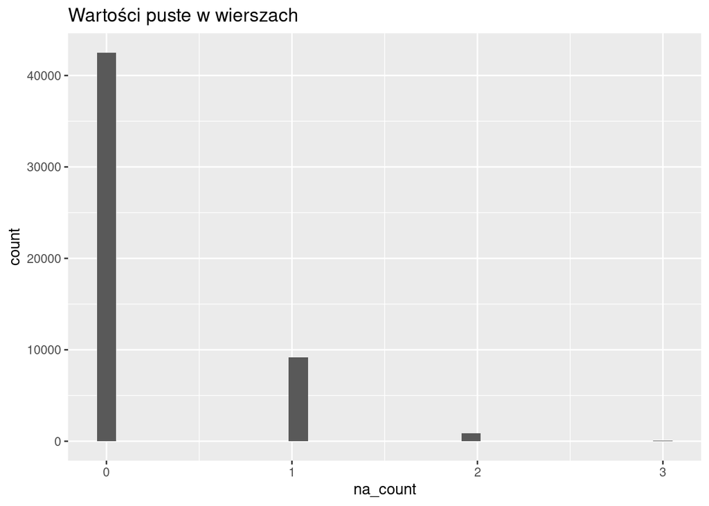

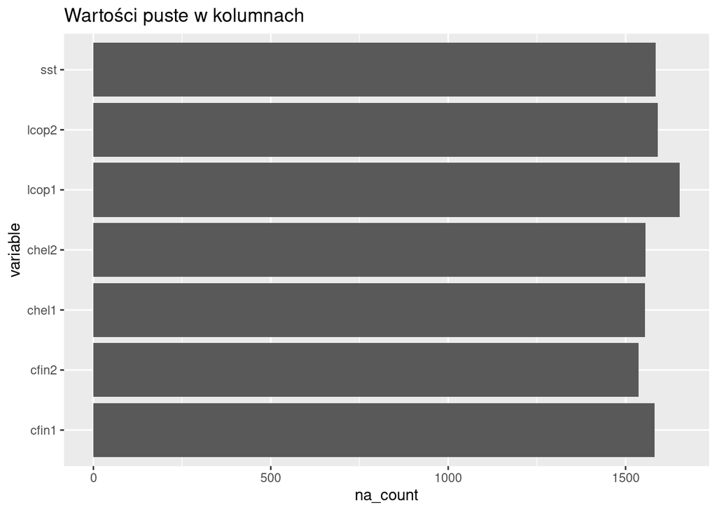

Widzimy, że 19.1966833% rekordów posiada conajmniej jedną wartość pustą. Wydaje się to być zbyt wiele, by po prostu odrzucić takie rekordy. Idealnie byłoby zastąpić takie wartości wartościami średnimi w danym roku, jednak nie posiadamy atrybutu rok, zamiast tego posłuzymy się wartością średnią w całym zbiorze.

## 2.5 Podsumowanie zbioru danych

Rozmiar zbioru: 52582 rekordów

Liczba wartości pustych: 0

Table continues below

| X | length | cfin1 | cfin2 |
| --- | --- | --- | --- |
| Min. : 0 | Min. :19.0 | Min. : 0.0000 | Min. : 0.0000 |
| 1st Qu.:13145 | 1st Qu.:24.0 | 1st Qu.: 0.0000 | 1st Qu.: 0.2778 |
| Median :26290 | Median :25.5 | Median : 0.1333 | Median : 0.7012 |
| Mean :26290 | Mean :25.3 | Mean : 0.4458 | Mean : 2.0248 |
| 3rd Qu.:39436 | 3rd Qu.:26.5 | 3rd Qu.: 0.3603 | 3rd Qu.: 1.9973 |
| Max. :52581 | Max. :32.5 | Max. :37.6667 | Max. :19.3958 |

Table continues below

| chel1 | chel2 | lcop1 | lcop2 |
| --- | --- | --- | --- |
| Min. : 0.000 | Min. : 5.238 | Min. : 0.3074 | Min. : 7.849 |
| 1st Qu.: 2.469 | 1st Qu.:13.589 | 1st Qu.: 2.5479 | 1st Qu.:17.808 |
| Median : 6.083 | Median :21.435 | Median : 7.1229 | Median :25.338 |
| Mean :10.006 | Mean :21.221 | Mean : 12.8108 | Mean :28.419 |
| 3rd Qu.:11.500 | 3rd Qu.:27.193 | 3rd Qu.: 21.2315 | 3rd Qu.:37.232 |
| Max. :75.000 | Max. :57.706 | Max. :115.5833 | Max. :68.736 |

Table continues below

| fbar | recr | cumf | totaln |
| --- | --- | --- | --- |
| Min. :0.0680 | Min. : 140515 | Min. :0.06833 | Min. : 144137 |
| 1st Qu.:0.2270 | 1st Qu.: 360061 | 1st Qu.:0.14809 | 1st Qu.: 306068 |
| Median :0.3320 | Median : 421391 | Median :0.23191 | Median : 539558 |
| Mean :0.3304 | Mean : 520366 | Mean :0.22981 | Mean : 514973 |
| 3rd Qu.:0.4560 | 3rd Qu.: 724151 | 3rd Qu.:0.29803 | 3rd Qu.: 730351 |
| Max. :0.8490 | Max. :1565890 | Max. :0.39801 | Max. :1015595 |

| sst | sal | xmonth | nao |
| --- | --- | --- | --- |
| Min. :12.77 | Min. :35.40 | Min. : 1.000 | Min. :-4.89000 |
| 1st Qu.:13.63 | 1st Qu.:35.51 | 1st Qu.: 5.000 | 1st Qu.:-1.89000 |
| Median :13.86 | Median :35.51 | Median : 8.000 | Median : 0.20000 |
| Mean :13.87 | Mean :35.51 | Mean : 7.258 | Mean :-0.09236 |
| 3rd Qu.:14.16 | 3rd Qu.:35.52 | 3rd Qu.: 9.000 | 3rd Qu.: 1.63000 |
| Max. :14.73 | Max. :35.61 | Max. :12.000 | Max. : 5.08000 |

Jak widzimy, wartości średnie nie uległy zmianie względem wcześniej odczytanych wartości.

## 2.6 Analiza rozkładów wartości atrybutów

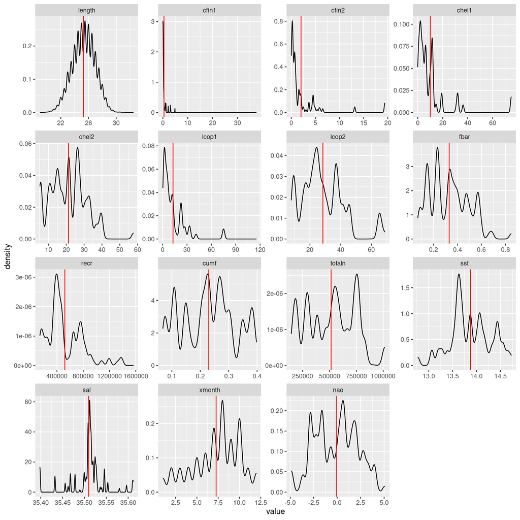

## 2.7 Korelacja między atrybutami

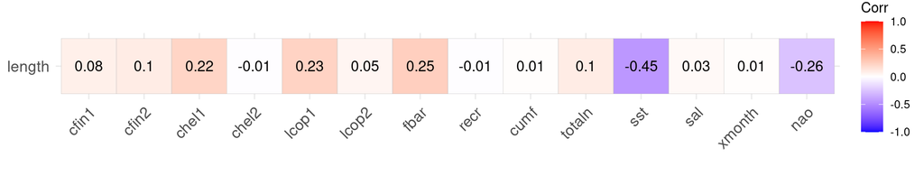

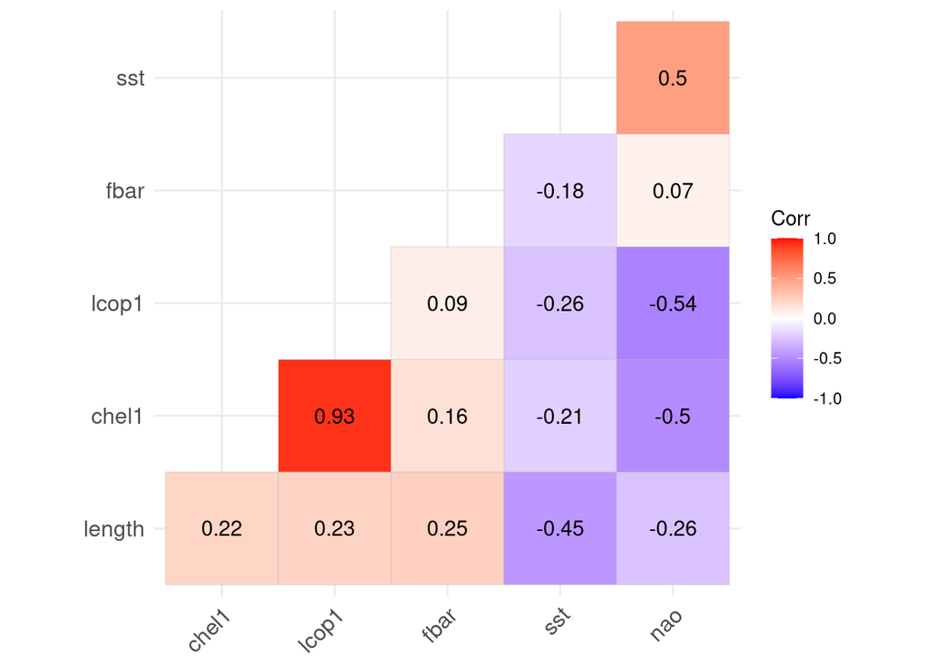

Najbardziej skorelowane z długością śledzia są atrybuty chel1, lcop1, fbar, sst, nao, jednocześnie możemy zauważyć bardzo dużą korelację atrybutów chel1 i lcop1.

## 2.8 Animacja zmiany rozkładu długości śledzi w różnych miesiącach

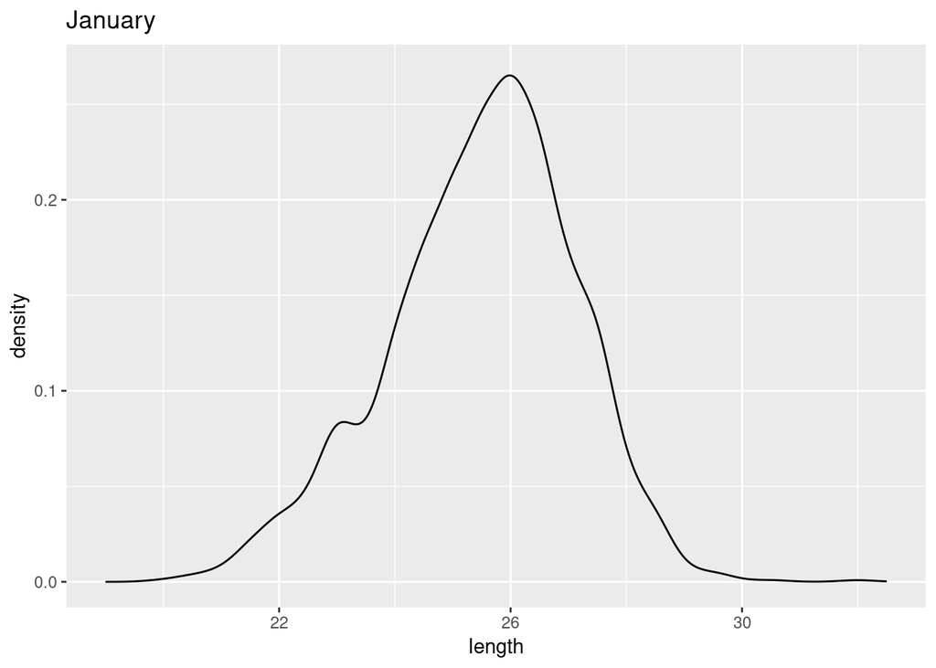

## 2.9 Regresor

```
## Random Forest
##
## 39438 samples
##     4 predictor
##
## No pre-processing
## Resampling: Cross-Validated (2 fold, repeated 5 times)
## Summary of sample sizes: 19718, 19720, 19720, 19718, 19720, 19718, ...
## Resampling results:
##
##   RMSE      Rsquared  MAE
##   1.191756  0.479794  0.9431913
##
## Tuning parameter 'mtry' was held constant at a value of 2
```

## 2.10 Wyniki na zbiorze testowym

| R2 | RMSE |
| --- | --- |
| 0.4868 | 1.185 |

## 2.11 Ważność atrybutów

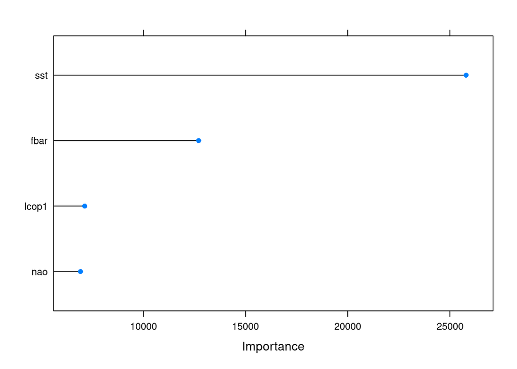

Jak widzimy najwięsza ważność cechuje:

- sst - temperatura przy powierzchni wody [°C] - wartość ta jest ujemnie skorelowana z długością śledzi, stąd wraz ze wzrostem temperatury obserwujemy spadek długości śledzia
- fbar - natężenie połowów w regionie [ułamek pozostawionego narybku] - wartość jest dadatnio skorelowana z długością śledzia, więc im mniejszy był ułamek pozostawionego narybku, tym mniejsza długość śledzi